# Sintaks ARIMA

# Packages yang digunakakan

```r
library(ggplot2)
library(tsibble)
library(tseries)
library(MASS)
library(forecast)
library(TSA)
library(TTR)
library(aTSA)
library(graphics)
```

## Penyiapan Data

```r
#Input data
meta = rio::import("https://raw.githubusercontent.com/mrnabilnaufal07/mpdw/main/KELOMPOK%206/saham_meta%20-%20Close.csv")
n = NROW(meta)

#Menghapus data Date dan Periode
meta.close <- meta$Close
View(meta)

#Mengubah tipe data menjadi time series
meta.ts<-ts(meta.close)
```

## Eksplorasi Data

### Plot Data Penuh

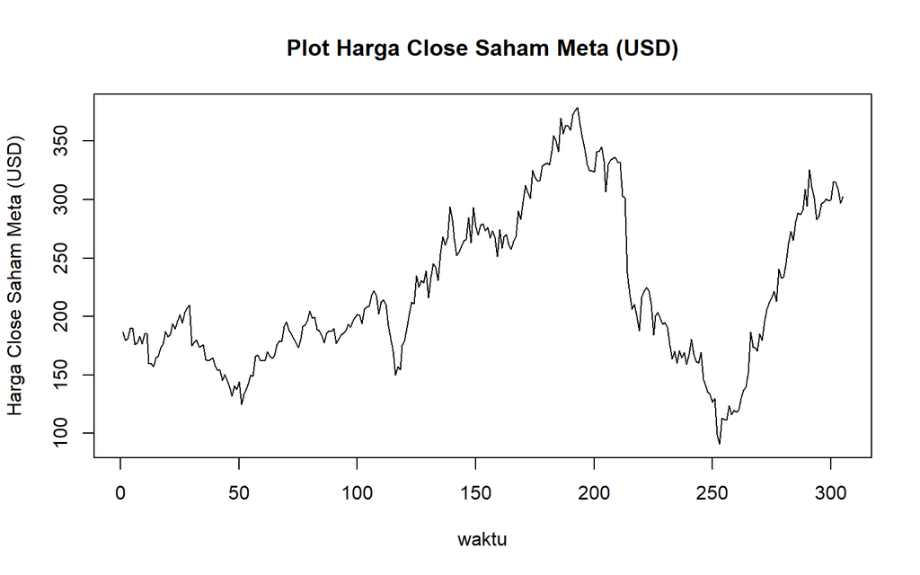

```r
plot.ts(meta.ts, xlab="waktu", ylab="Harga Close Saham Meta (USD)", main="Plot Harga Close Saham Meta (USD)")
```

Berdasarkan plot data deret waktu, terlihat bahwa data memiliki pola tren naik pada periode 1 hingga 190 an. Namun, memasuki periode 200 tren data mulai menurun Berdasarkan pola data, pembagian data latih dan data uji ditetapkan dengan proporsi 90%:10%.

### Plot Data Latih

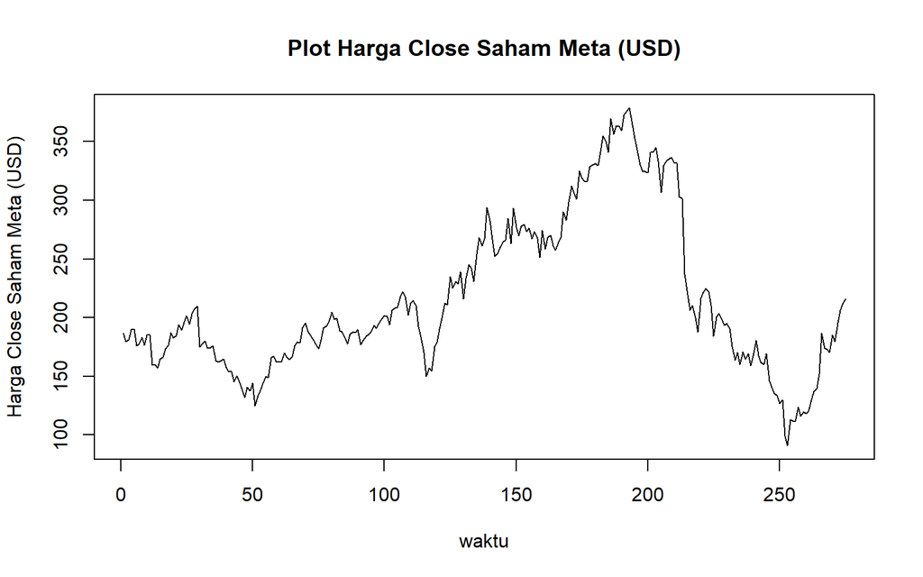

```r
meta.train<-meta$Close[1:275]
train.ts<-ts(meta.train)
plot.ts(train.ts, lty=1, xlab="waktu", ylab="Harga Close Saham Meta (USD)", main="Plot Harga Close Saham Meta (USD)")
```

Berdasarkan plot data deret waktu pada data latih, terlihat bahwa data cenderung memiliki trend yang naik dan turun. Hal ini mengindikasikan bahwa data tidak stasioner dalam rataan.

### Plot Data Uji

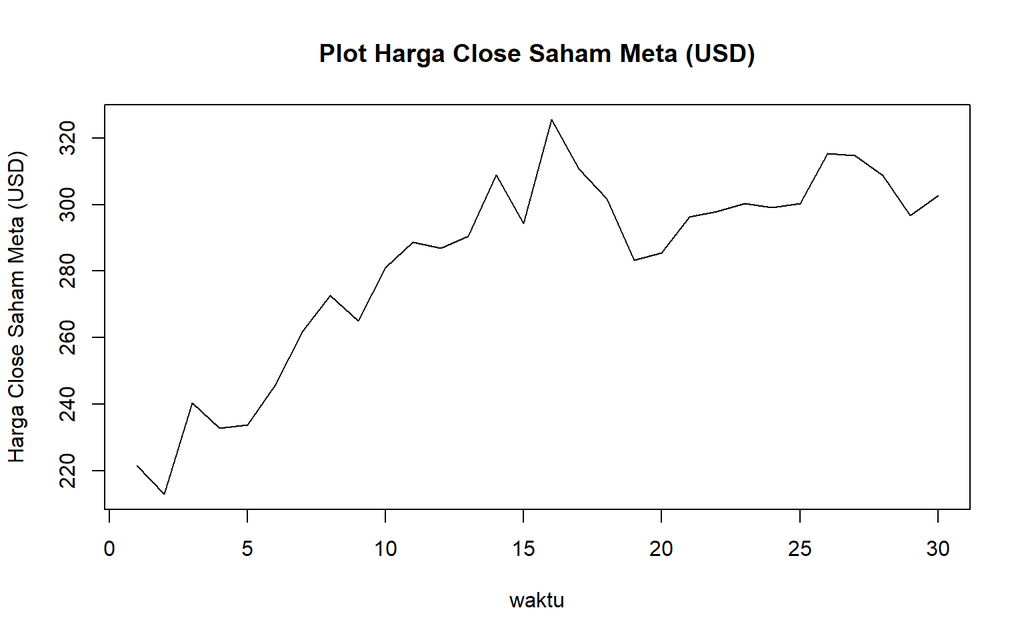

```r
meta.test<-meta$Close[276:305]
test.ts<-ts(meta.test)
plot.ts(test.ts, lty=1, xlab="waktu", ylab="Harga Close Saham Meta (USD)", main="Plot Harga Close Saham Meta (USD)")
```

## Kestasioneran Dalam Ragam

### Plot Box-Cox

```r
index <- seq(1:275)
bc = boxcox(train.ts~index, lambda = seq(-1,0.5,by=0.01))
```

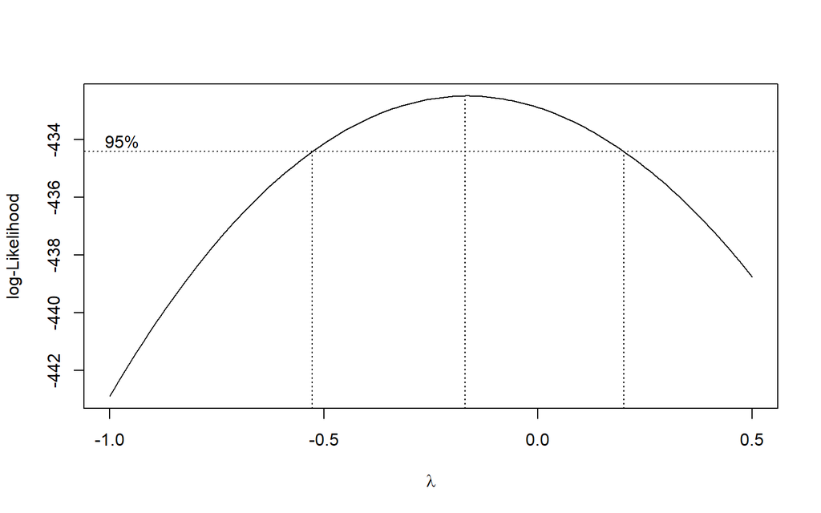

```r
#Nilai Rounded Lambda
lambda <- bc$x[which.max(bc$y)]
lambda
```

```
## [1] -0.17
```

```r
#SK
bc$x[bc$y > max(bc$y) - 1/2 * qchisq(.95,1)]
```

```
##  [1] -0.52 -0.51 -0.50 -0.49 -0.48 -0.47 -0.46 -0.45 -0.44 -0.43 -0.42 -0.41
## [13] -0.40 -0.39 -0.38 -0.37 -0.36 -0.35 -0.34 -0.33 -0.32 -0.31 -0.30 -0.29
## [25] -0.28 -0.27 -0.26 -0.25 -0.24 -0.23 -0.22 -0.21 -0.20 -0.19 -0.18 -0.17
## [37] -0.16 -0.15 -0.14 -0.13 -0.12 -0.11 -0.10 -0.09 -0.08 -0.07 -0.06 -0.05
## [49] -0.04 -0.03 -0.02 -0.01  0.00  0.01  0.02  0.03  0.04  0.05  0.06  0.07
## [61]  0.08  0.09  0.10  0.11  0.12  0.13  0.14  0.15  0.16  0.17  0.18  0.19
## [73]  0.20
```

Plot Boxcox menunjukkan nilai *rounded value* ($\lambda$) optimum sebesar **-0.17** dan pada selang kepercayaan 95% nilai memiliki batas bawah **-0.52** dan batas atas **0.20**. Selang tersebut tidak memuat nilai satu sehingga dapat dikatakan bahwa data yang digunakan tidak stasioner dalam ragam. Nilai lambda = 0 dipilih untuk melakukan transformasi,dengan transformasi yang digunakan adalah logaritma natural.

### Penanganan Ketidakstasioneran dalam ragam (Lambda = 0)

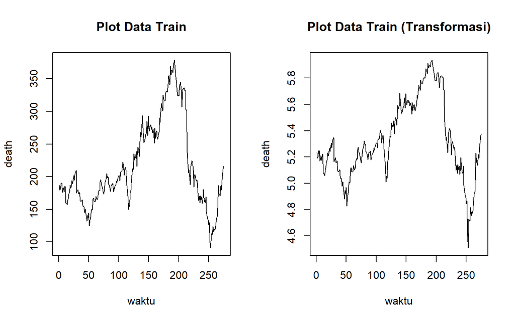

```r
# transformasi dengan nilai lambda = 0
data_boxcox = log(train.ts)

par(mfrow=c(1,2))
plot.ts(train.ts, lty=1, xlab="waktu", ylab="death", main="Plot Data Train")
plot.ts(data_boxcox, lty=1, xlab="waktu", ylab="death", main="Plot Data Train (Transformasi)")
```

### Plot Box-Cox

```r
index2 <- seq(1:275)
bc2 = boxcox(data_boxcox~index, lambda = seq(-2,2.5,by=0.01))
```

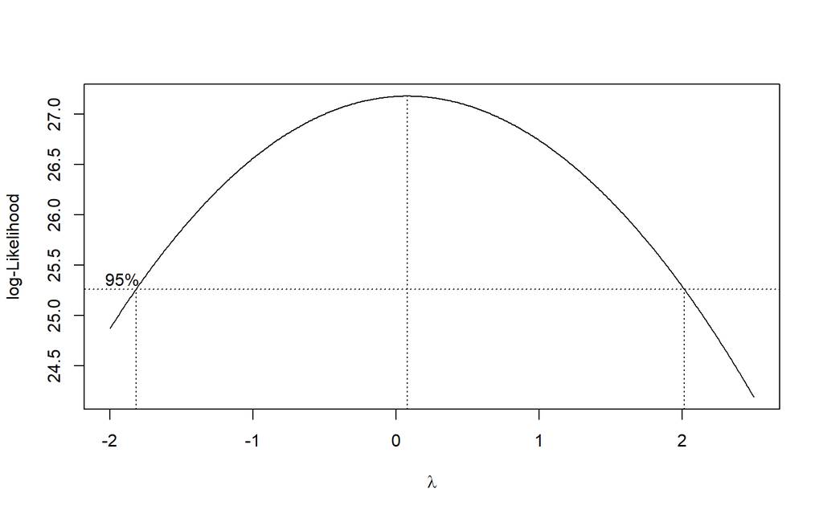

```r
#Nilai Rounded Lambda
lambda2 <- bc2$x[which.max(bc2$y)]
lambda2
```

```
## [1] 0.08
```

```r
#SK
bc2$x[bc2$y > max(bc2$y) - 1/2 * qchisq(.95,1)]
```

```
##   [1] -1.81 -1.80 -1.79 -1.78 -1.77 -1.76 -1.75 -1.74 -1.73 -1.72 -1.71 -1.70
##  [13] -1.69 -1.68 -1.67 -1.66 -1.65 -1.64 -1.63 -1.62 -1.61 -1.60 -1.59 -1.58
##  [25] -1.57 -1.56 -1.55 -1.54 -1.53 -1.52 -1.51 -1.50 -1.49 -1.48 -1.47 -1.46
##  [37] -1.45 -1.44 -1.43 -1.42 -1.41 -1.40 -1.39 -1.38 -1.37 -1.36 -1.35 -1.34
##  [49] -1.33 -1.32 -1.31 -1.30 -1.29 -1.28 -1.27 -1.26 -1.25 -1.24 -1.23 -1.22
##  [61] -1.21 -1.20 -1.19 -1.18 -1.17 -1.16 -1.15 -1.14 -1.13 -1.12 -1.11 -1.10
##  [73] -1.09 -1.08 -1.07 -1.06 -1.05 -1.04 -1.03 -1.02 -1.01 -1.00 -0.99 -0.98
##  [85] -0.97 -0.96 -0.95 -0.94 -0.93 -0.92 -0.91 -0.90 -0.89 -0.88 -0.87 -0.86
##  [97] -0.85 -0.84 -0.83 -0.82 -0.81 -0.80 -0.79 -0.78 -0.77 -0.76 -0.75 -0.74
## [109] -0.73 -0.72 -0.71 -0.70 -0.69 -0.68 -0.67 -0.66 -0.65 -0.64 -0.63 -0.62
## [121] -0.61 -0.60 -0.59 -0.58 -0.57 -0.56 -0.55 -0.54 -0.53 -0.52 -0.51 -0.50
## [133] -0.49 -0.48 -0.47 -0.46 -0.45 -0.44 -0.43 -0.42 -0.41 -0.40 -0.39 -0.38
## [145] -0.37 -0.36 -0.35 -0.34 -0.33 -0.32 -0.31 -0.30 -0.29 -0.28 -0.27 -0.26
## [157] -0.25 -0.24 -0.23 -0.22 -0.21 -0.20 -0.19 -0.18 -0.17 -0.16 -0.15 -0.14
## [169] -0.13 -0.12 -0.11 -0.10 -0.09 -0.08 -0.07 -0.06 -0.05 -0.04 -0.03 -0.02
```

[output cut: 17 more lines]

Plot Boxcox memuat nilai satu sehingga dapat dikatakan bahwa data yang digunakan sudah stasioner dalam ragam.

## Kestasioneran Dalam Rataan

### Plot ACF

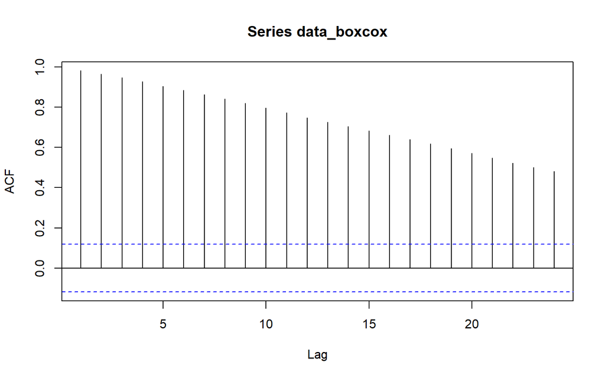

```r
acf(data_boxcox)
```

Berdasarkan plot ACF, terlihat bahwa plot ACF data menurun secara perlahan (*tails of slowly*). Hal ini juga menjadi indikasi bahwa data tidak stasioner dalam rataan

### Uji ADF

```r
tseries::adf.test(data_boxcox)
```

```
##
##  Augmented Dickey-Fuller Test
##
## data:  data_boxcox
## Dickey-Fuller = -1.7717, Lag order = 6, p-value = 0.6722
## alternative hypothesis: stationary
```

$H_0$ : Data tidak stasioner dalam rataan

$H_1$ : Data stasioner dalam rataan

Berdasarkan uji ADF tersebut, didapat *p-value* sebesar 0.6722 yang lebih besar dari taraf nyata 5% sehingga tak tolak $H_0$ dan menandakan bahwa data tidak stasioner dalam rataan. Hal ini sesuai dengan hasil eksplorasi menggunakan plot time series dan plot ACF, sehingga ketidakstasioneran model kedepannya harus ditangani.

### Penanganan Ketidakstasioneran dalam rataan

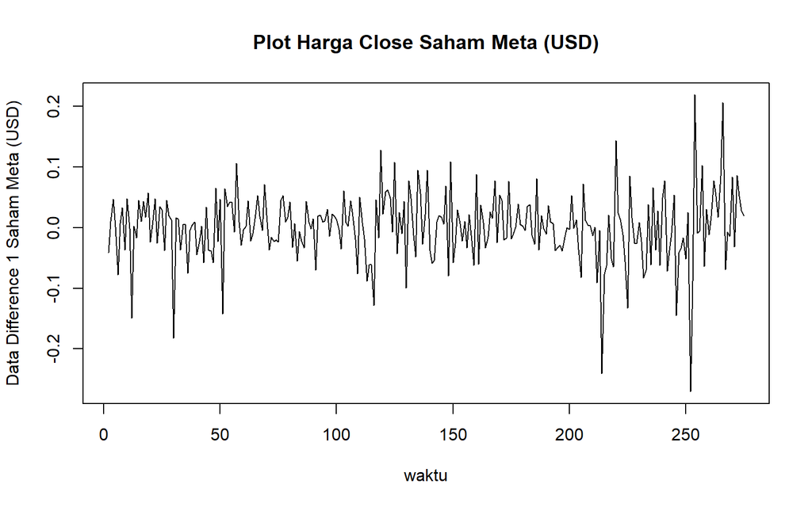

```r
train.diff<-diff(data_boxcox,differences = 1)
plot.ts(train.diff, lty=1, xlab="waktu", ylab="Data Difference 1 Saham Meta (USD)", main="Plot Harga Close Saham Meta (USD)")
```

Berdasarkan plot data deret waktu, terlihat bahwa data sudah stasioner dalam rataan ditandai dengan data bergerak pada nilai tengah tertentu (tidak terdapat trend ataupun musiman pada data)

#### Plot ACF

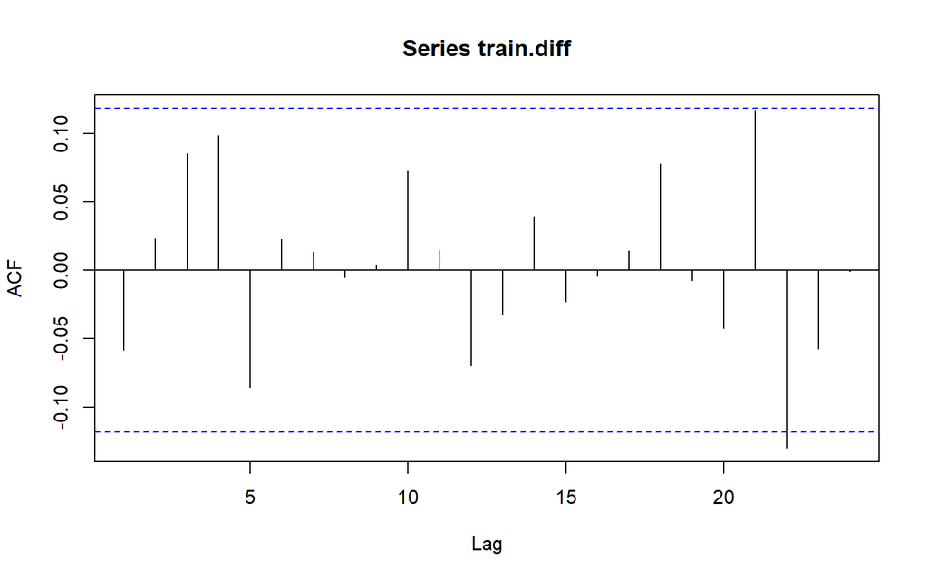

```r
acf(train.diff)
```

Berdasarkan plot tersebut, tidak terlihat adanya *tailss off slowly*. Namun, akan dipastikan kembali dengan pengujian formal.

#### Uji ADF

```r
tseries::adf.test(train.diff)
```

```
##
##  Augmented Dickey-Fuller Test
##
## data:  train.diff
## Dickey-Fuller = -5.6838, Lag order = 6, p-value = 0.01
## alternative hypothesis: stationary
```

$H_0$ : Data tidak stasioner dalam rataan

$H_1$ : Data stasioner dalam rataan

Berdasarkan uji ADF tersebut, didapat *p-value* sebesar 0.01 yang lebih kecil dari taraf nyata 5% sehingga tolak $H_0$ atau data stasioner dalam rataan. Dalam hal ini ketidakstasioneran data dalam rataan sudah berhasil ditangani dan dapat dilanjutkan ke identifikasi model.

## Identifikasi Model

### Plot ACF

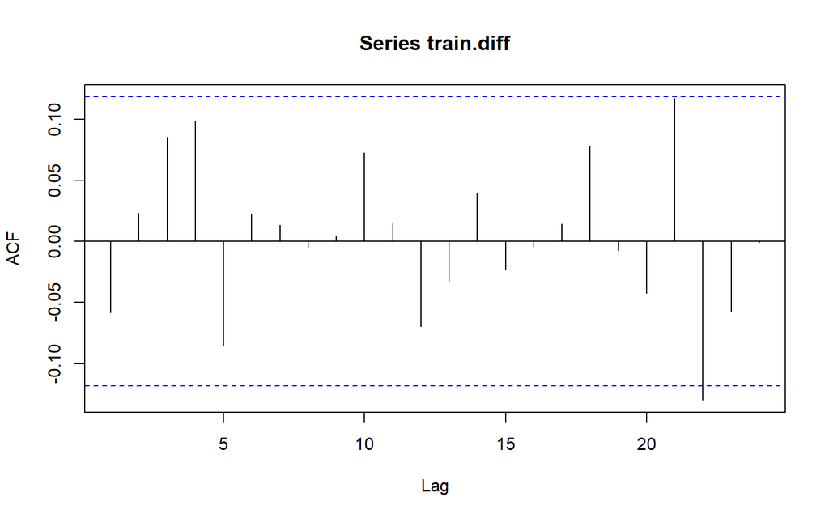

```r
acf(train.diff)
```

Berdasarkan plot tersebut, terlihat bahwa plot ACF tidak *cuts off*.

### Plot PACF

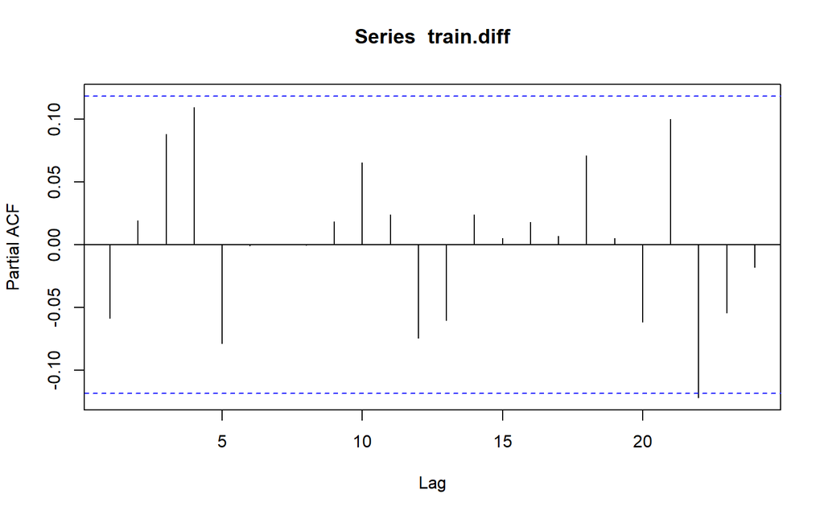

```r
pacf(train.diff)
```

Berdasarkan plot tersebut, terlihat bahwa plot PACF tidak *cuts off*.

Tidak dapat mengidentifikasi model menggunakan plot ACF dan PACF

### Plot EACF

```r
eacf(train.diff)
```

```
## AR/MA
##   0 1 2 3 4 5 6 7 8 9 10 11 12 13
## 0 o o o o o o o o o o o  o  o  o
## 1 x o o o o o o o o o o  o  o  o
## 2 x x o o o o o o o o o  o  o  o
## 3 x x x o o o o o o o o  o  o  o
## 4 x x o o o o o o o o o  o  o  o
## 5 o o o o o o o o o o o  o  o  o
## 6 x o o o o o o o o o o  o  o  o
## 7 o o o o o o x o o o o  o  o  o
```

Identifikasi model menggunakan plot EACF dilakukan dengan melihat ujung segitiga pada pola segitiga nol. Dalam hal ini model tentatif yang terbentuk adalah ARIMA(1,1,1),(2,1,2), (3,1,3)

Untuk keperluan eksplorasi ARIMA(0,1,1)

## Pendugaan Parameter Model Tentatif

### ARIMA(1,1,1)

```r
model1.da=Arima(data_boxcox, order=c(1,1,1),method="ML")
summary(model1.da) #AIC=-790.36
```

```
## Series: data_boxcox
## ARIMA(1,1,1)
##
## Coefficients:
##           ar1     ma1
##       -0.1447  0.0876
## s.e.   0.5950  0.5961
##
## sigma^2 = 0.003225:  log likelihood = 398.18
## AIC=-790.36   AICc=-790.27   BIC=-779.52
##
## Training set error measures:
##                        ME       RMSE        MAE        MPE      MAPE      MASE
## Training set 0.0005725358 0.05647433 0.04057693 0.00453167 0.7727692 0.9964432
##                       ACF1
## Training set -0.0006388511
```

```r
lmtest::coeftest(model1.da) #seluruh parameter tidak signifikan
```

```
##
## z test of coefficients:
##
##      Estimate Std. Error z value Pr(>|z|)
## ar1 -0.144711   0.595013 -0.2432   0.8078
## ma1  0.087634   0.596117  0.1470   0.8831
```

### ARIMA(2,1,2)

```r
model2.da=Arima(data_boxcox, order=c(2,1,2),method="ML")
summary(model2.da) #AIC=-792.21
```

```
## Series: data_boxcox
## ARIMA(2,1,2)
##
## Coefficients:
##          ar1      ar2      ma1     ma2
##       0.8845  -0.6766  -0.9619  0.7931
## s.e.  0.1782   0.1851   0.1490  0.1545
##
## sigma^2 = 0.003178:  log likelihood = 401.11
## AIC=-792.21   AICc=-791.99   BIC=-774.14
##
## Training set error measures:
##                        ME       RMSE        MAE         MPE     MAPE      MASE
## Training set 0.0005357446 0.05586216 0.04043367 0.004527275 0.770401 0.9929253
##                     ACF1
## Training set 0.008159536
```

```r
lmtest::coeftest(model2.da) #seluruh parameter signifikan
```

```
##
## z test of coefficients:
##
##     Estimate Std. Error z value  Pr(>|z|)
## ar1  0.88450    0.17825  4.9622 6.969e-07 ***
## ar2 -0.67665    0.18508 -3.6559 0.0002563 ***
## ma1 -0.96193    0.14900 -6.4561 1.074e-10 ***
## ma2  0.79313    0.15445  5.1351 2.819e-07 ***
## ---
## Signif. codes:  0 '***' 0.001 '**' 0.01 '*' 0.05 '.' 0.1 ' ' 1
```

### ARIMA(3,1,3)

```r
model3.da=Arima(data_boxcox, order=c(3,1,3))
summary(model3.da) #AIC=-789.1
```

```
## Series: data_boxcox
## ARIMA(3,1,3)
##
## Coefficients:
##          ar1      ar2      ar3      ma1     ma2     ma3
##       0.0455  -0.1353  -0.7932  -0.1294  0.1870  0.8393
## s.e.  0.1892   0.1711   0.1708   0.1974  0.1912  0.1964
##
## sigma^2 = 0.003147:  log likelihood = 401.55
## AIC=-789.1   AICc=-788.68   BIC=-763.81
##
## Training set error measures:
##                        ME      RMSE        MAE         MPE      MAPE      MASE
## Training set 0.0005735163 0.0553824 0.04012724 0.005032117 0.7644129 0.9854001
##                     ACF1
## Training set 0.009831667
```

```r
lmtest::coeftest(model3.da) #hanya ar3 dan ma3 yang signifikan
```

```
##
## z test of coefficients:
##
##      Estimate Std. Error z value  Pr(>|z|)
## ar1  0.045516   0.189211  0.2406    0.8099
## ar2 -0.135349   0.171149 -0.7908    0.4290
## ar3 -0.793248   0.170788 -4.6446 3.407e-06 ***
## ma1 -0.129374   0.197368 -0.6555    0.5121
## ma2  0.187026   0.191233  0.9780    0.3281
## ma3  0.839281   0.196357  4.2743 1.918e-05 ***
## ---
## Signif. codes:  0 '***' 0.001 '**' 0.01 '*' 0.05 '.' 0.1 ' ' 1
```

### ARIMA(0,1,1)

```r
model4.da=Arima(data_boxcox, order=c(0,1,1),method="ML")
summary(model4.da) #AIC=-792.29
```

```
## Series: data_boxcox
## ARIMA(0,1,1)
##
## Coefficients:
##           ma1
##       -0.0549
## s.e.   0.0581
##
## sigma^2 = 0.003214:  log likelihood = 398.14
## AIC=-792.29   AICc=-792.24   BIC=-785.06
##
## Training set error measures:
##                        ME       RMSE        MAE         MPE      MAPE      MASE
## Training set 0.0005743537 0.05648205 0.04056465 0.004536052 0.7725271 0.9961417
##                      ACF1
## Training set -0.002254417
```

```r
lmtest::coeftest(model4.da) #tidak ada yang signifikan
```

```
##
## z test of coefficients:
##
##      Estimate Std. Error z value Pr(>|z|)
## ma1 -0.054860   0.058075 -0.9446   0.3448
```

```r
knitr::kable(
  cbind(c("ARIMA (1,1,1)","ARIMA (2,1,2)","ARIMA (3,1,3)","ARIMA(0,1,1)"),
        c(model1.da$aic,model2.da$aic,model3.da$aic,model4.da$aic)),
  col.names=c("Model","AIC")
)
```

| Model | AIC |
| --- | --- |
| ARIMA (1,1,1) | -790.363803598181 |
| ARIMA (2,1,2) | -792.210272086609 |
| ARIMA (3,1,3) | -789.099971130887 |
| ARIMA(0,1,1) | -792.289206502365 |

Berdasarkan pendugaan parameter di atas, model ARIMA(2,1,2) dengan seluruh parameternya signifikan pada taraf 5% dan AIC kedua terkecil. Oleh karena itu model ARIMA(2,1,2) dipilih untuk proses berikutnya

## Analisis Sisaan

Model terbaik hasil identifikasi kemudian dicek asumsi sisaannya. Sisaan model ARIMA harus memenuhi asumsi normalitas, kebebasan sisaan, dan kehomogenan ragam. Diagnostik model dilakukan secara eksplorasi dan uji formal.

### Eksplorasi Sisaan

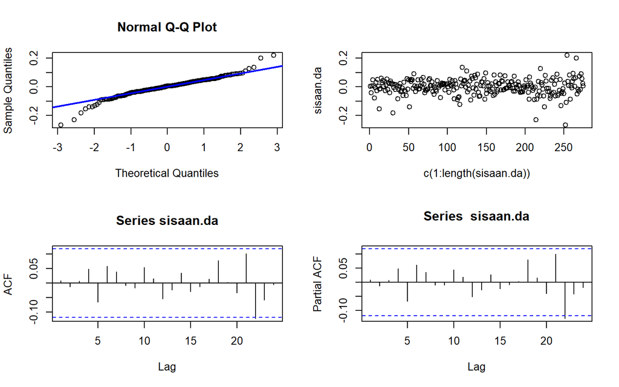

```r
#Eksplorasi
sisaan.da <- model2.da$residuals
par(mfrow=c(2,2))
qqnorm(sisaan.da)
qqline(sisaan.da, col = "blue", lwd = 2)
plot(c(1:length(sisaan.da)),sisaan.da)
acf(sisaan.da)
pacf(sisaan.da)
```

```r
par(mfrow = c(1,1))
```

Berdasarkan plot kuantil-kuantil normal, secara eksplorasi ditunjukkan sisaan tidak menyebar normal ditandai dengan titik titik yang cenderung tidak mengikuti garis $45^{\circ}$. Kemudian dapat dilihat juga lebar pita sisaan yang cenderung sama menandakan bahwa sisaan memiliki ragam yang homogen. Plot ACF dan PACF sisaan ARIMA(2,1,2) tidak ada yang signifikan pada 20 lag awal yang menandakan sisaan saling bebas. Kondisi ini akan diuji lebih lanjut dengan uji formal.

### Uji Formal

```r
#1) Sisaan Menyebar Normal
tseries::jarque.bera.test(sisaan.da);  #tak tolak H0 > sisaan menyebar normal
```

```
##
##  Jarque Bera Test
##
## data:  sisaan.da
## X-squared = 165.7, df = 2, p-value < 2.2e-16
```

Selain dengan eksplorasi, asumsi tersebut dapat diuji menggunakan uji formal. Pada tahapan ini uji formal yang digunakan untuk normalitas adalah uji Jarque Bera . Hipotesis pada uji Jarque Bera adalah sebagai berikut.

$H_0$ : Sisaan menyebar normal

$H_1$ : Sisaan tidak menyebar normal

Berdasarkan uji Jarque-Bera tersebut, didapat *p-value* kurang dari 2.2e-16 yang kurang dari taraf nyata 5% sehingga tolak $H_0$ dan menandakan bahwa sisaan tidak menyebar normal. Hal ini sesuai dengan hasil eksplorasi menggunakan plot kuantil-kuantil normal.

```r
#2) Sisaan saling bebas/tidak ada autokorelasi
Box.test(sisaan.da, type = "Ljung")  #tak tolak H0 > sisaan saling bebas
```

```
##
##  Box-Ljung test
##
## data:  sisaan.da
## X-squared = 0.018509, df = 1, p-value = 0.8918
```

Selanjutnya akan dilakukan uji formal untuk kebebasan sisaan menggunakan uji Ljung-Box. Hipotesis yang digunakan adalah sebagai berikut.

$H_0$ : Sisaan saling bebas

$H_1$ : Sisaan tidak tidak saling bebas

Berdasarkan uji Ljung-Box tersebut, didapat *p-value* sebesar 0.8918 yang lebih besar dari taraf nyata 5% sehingga tak tolak $H_0$ dan menandakan bahwa sisaan saling bebas/tidak ada autokorelasi.

```r
#3) Sisaan homogen
Box.test((sisaan.da)^2, type = "Ljung")  #tak tolak H0 > sisaan homogen
```

```
##
##  Box-Ljung test
##
## data:  (sisaan.da)^2
## X-squared = 1.3211, df = 1, p-value = 0.2504
```

Hipotesis yang digunakan untuk uji kehomogenan ragam adalah sebagai berikut.

$H_0$ : Ragam sisaan homogen

$H_1$ : Ragam sisaan tidak homogen

Berdasarkan uji Ljung-Box terhadap sisaan kuadrat tersebut, didapat *p-value* sebesar 0.2504 yang lebih dari taraf nyata 5% sehingga tak tolak $H_0$ dan menandakan bahwa ragam sisaan homogen.

```r
#4) Nilai tengah sisaan sama dengan nol
t.test(sisaan.da, mu = 0, conf.level = 0.95)  #tak tolak h0 > nilai tengah sisaan sama dengan 0
```

```
##
##  One Sample t-test
##
## data:  sisaan.da
## t = 0.15876, df = 274, p-value = 0.874
## alternative hypothesis: true mean is not equal to 0
## 95 percent confidence interval:
##  -0.006107697  0.007179186
## sample estimates:
##    mean of x
## 0.0005357446
```

Terakhir, dengan uji-t, akan dicek apakah nilai tengah sisaan sama dengan nol. Hipotesis yang diujikan sebagai berikut.

$H_0$ : nilai tengah sisaan sama dengan 0

$H_1$ : nilai tengah sisaan tidak sama dengan 0

Berdasarkan uji-ttersebut, didapat *p-value* sebesar 0.874 yang lebih besar dari taraf nyata 5% sehingga tak tolak $H_0$ dan menandakan bahwa nilai tengah sisaan sama dengan nol. Hal ini sama dengan hasil eksplorasi.

## Overfitting

Tahapan selanjutnya adalah *overfitting* dilakukan dengan menaikkan orde AR(p) dan MA(q) dari model ARIMA(2,1,2) untuk melihat apakah terdapat model lain yang lebih baik dari model saat ini. Kandidat model *overfitting* adalah ARIMA(2,1,3) dan ARIMA(3,1,2).

### Model ARIMA(2,1,3)

```r
model.overfit1=Arima(data_boxcox, order=c(2,1,3),method="ML")
summary(model.overfit1) #-790.28
```

```
## Series: data_boxcox
## ARIMA(2,1,3)
##
## Coefficients:
##          ar1      ar2      ma1     ma2     ma3
##       0.8273  -0.6387  -0.8960  0.7367  0.0253
## s.e.  0.3046   0.2659   0.3111  0.2932  0.0954
##
## sigma^2 = 0.003189:  log likelihood = 401.14
## AIC=-790.28   AICc=-789.97   BIC=-768.6
##
## Training set error measures:
##                        ME      RMSE        MAE         MPE      MAPE      MASE
## Training set 0.0005298075 0.0558551 0.04042824 0.004519325 0.7703156 0.9927918
##                       ACF1
## Training set -0.0003483687
```

```r
lmtest::coeftest(model.overfit1) #ma3 tidak signifikan
```

```
##
## z test of coefficients:
##
##      Estimate Std. Error z value Pr(>|z|)
## ar1  0.827344   0.304625  2.7159 0.006609 **
## ar2 -0.638701   0.265866 -2.4023 0.016291 *
## ma1 -0.896035   0.311092 -2.8803 0.003973 **
## ma2  0.736692   0.293205  2.5125 0.011986 *
## ma3  0.025332   0.095443  0.2654 0.790692
## ---
## Signif. codes:  0 '***' 0.001 '**' 0.01 '*' 0.05 '.' 0.1 ' ' 1
```

### Model ARIMA(3,1,2)

```r
model.overfit2=Arima(data_boxcox, order=c(3,1,2),method="ML")
summary(model.overfit2) #-790.28
```

```
## Series: data_boxcox
## ARIMA(3,1,2)
##
## Coefficients:
##          ar1      ar2     ar3      ma1     ma2
##       0.8611  -0.6674  0.0202  -0.9303  0.7690
## s.e.  0.2191   0.2103  0.0789   0.2112  0.2053
##
## sigma^2 = 0.003189:  log likelihood = 401.14
## AIC=-790.28   AICc=-789.96   BIC=-768.6
##
## Training set error measures:
##                        ME       RMSE        MAE         MPE      MAPE      MASE
## Training set 0.0005300233 0.05585548 0.04042884 0.004520478 0.7703243 0.9928066
##                      ACF1
## Training set 0.0001175852
```

```r
lmtest::coeftest(model.overfit2) #ar3 tidak signifikan
```

```
##
## z test of coefficients:
##
##      Estimate Std. Error z value  Pr(>|z|)
## ar1  0.861141   0.219081  3.9307 8.470e-05 ***
## ar2 -0.667431   0.210323 -3.1734 0.0015068 **
## ar3  0.020182   0.078934  0.2557 0.7981980
## ma1 -0.930307   0.211155 -4.4058 1.054e-05 ***
## ma2  0.769010   0.205300  3.7458 0.0001798 ***
## ---
## Signif. codes:  0 '***' 0.001 '**' 0.01 '*' 0.05 '.' 0.1 ' ' 1
```

model yang dipilih tetap model ARIMA(2,1,2)

## Peramalan

Peramalan dilakukan menggunakan fungsi `forecast()` . Contoh peramalan berikut ini dilakukan untuk 30 periode ke depan.

```r
#---FORECAST---#
ramalan.da <- forecast::forecast(model2.da, h = 30)
ramalan.da
```

```
##     Point Forecast    Lo 80    Hi 80    Lo 95    Hi 95
## 276       5.386578 5.314328 5.458828 5.276081 5.497075
## 277       5.388176 5.289875 5.486478 5.237838 5.538515
## 278       5.382257 5.261508 5.503007 5.197587 5.566928
## 279       5.375940 5.232742 5.519139 5.156937 5.594943
## 280       5.374358 5.209990 5.538726 5.122979 5.625737
## 281       5.377233 5.194719 5.559748 5.098101 5.656365
## 282       5.380847 5.183282 5.578411 5.078698 5.682995
## 283       5.382097 5.171386 5.592809 5.059842 5.704353
## 284       5.380759 5.157536 5.603981 5.039369 5.722148
## 285       5.378728 5.143035 5.614422 5.018266 5.739191
## 286       5.377838 5.129851 5.625825 4.998574 5.757102
## 287       5.378425 5.118738 5.638112 4.981267 5.775582
## 288       5.379546 5.108953 5.650139 4.965710 5.793382
## 289       5.380141 5.099302 5.660980 4.950634 5.809647
```

[output cut: 16 more lines]

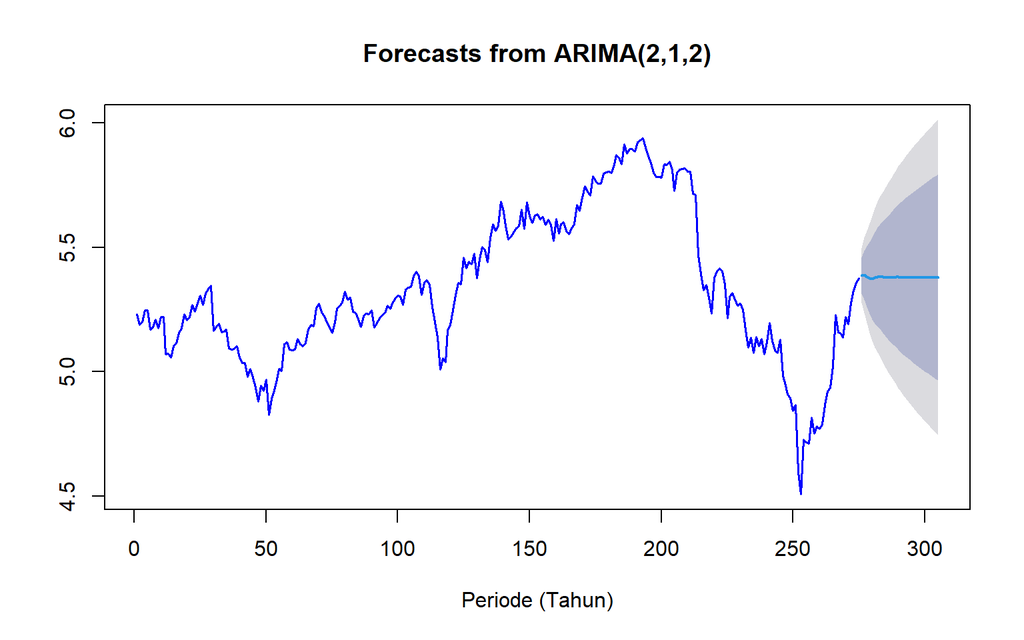

```r
data.ramalan.da <- ramalan.da$mean
plot(ramalan.da, xlab="Periode (Tahun)", col = "blue", lwd=1.5)
```

Berdasarkan hasil plot ramalan di atas, dapat dilihat bahwa ramalan ARIMA(2,1,2) cenderung stabil hingga akhir periode. Selanjutnya, dapat dicari nilai akurasi antara hasil ramalan dengan data uji sebagai berikut.

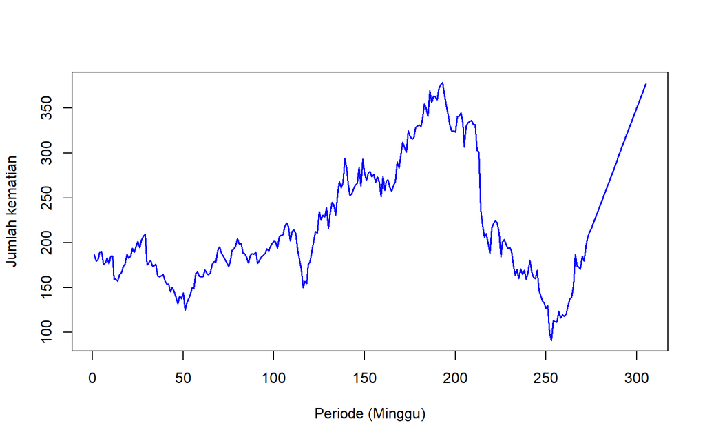

```r
pt_1 <- (exp(data_boxcox[length(data_boxcox)])) #nilai akhir data latih
hasil.forc.Diff <- data.ramalan.da
hasil <- diffinv(hasil.forc.Diff, differences = 1) + pt_1

#has.1 sama hasilnta dengan: cumsum(c(pt_1,hasil.forc.Diff))
ts.plot(train.ts,hasil, ylab="Jumlah kematian",
        xlab = "Periode (Minggu)",
        col = "blue", lwd=1.5)
```

```r
perbandingan.da<-matrix(data=c(head(test.ts, n=30), hasil[-1]),
                     nrow = 30, ncol = 2)
colnames(perbandingan.da)<-c("Aktual","Hasil Forecast")
perbandingan.da
```

```
##       Aktual Hasil Forecast
##  [1,] 221.49       221.4866
##  [2,] 212.89       226.8748
##  [3,] 240.32       232.2570
##  [4,] 232.78       237.6330
##  [5,] 233.81       243.0073
##  [6,] 245.64       248.3845
##  [7,] 262.04       253.7654
##  [8,] 272.61       259.1475
##  [9,] 264.95       264.5282
## [10,] 281.00       269.9070
## [11,] 288.73       275.2848
## [12,] 286.98       280.6632
## [13,] 290.53       286.0428
## [14,] 308.87       291.4229
```

[output cut: 16 more lines]

```r
accuracy(ts(hasil[-1]), head(test.ts, n=30))
```

```
##                 ME     RMSE     MAE      MPE     MAPE      ACF1 Theil's U
## Test set -16.97444 32.54952 24.2732 -5.71993 8.239161 0.8240846  2.358312
```

Kesimpulan: Model ARIMA(2,1,2) terpilih.